# The Carpentries: Programmatic Assessment Report

**January 1, 2012 to September 30, 2018**

**Authors: Maneesha Sane, Erin Becker**

## What is The Carpentries?

Software Carpentry (SWC) and Data Carpentry (DC) are two lesson programs of The Carpentries (a fiscally sponsored project of Community Initiatives). We teach essential computing and data skills. We exist because the skills needed to do computational, data-intensive research are not part of basic research training in most disciplines.

## About Software Carpentry

Software Carpentry enables researchers to create purpose-built tools, whether it be a Unix shell script to automate repetitive tasks, or software code in programming languages such as Python, R, or MATLAB. These enable researchers to build programs that can be read, re-used, and validated, greatly enhancing the sharing and reproducibility of their research.

## About Data Carpentry

Data Carpentry learners are taught to work with data more effectively. Workshops focus on the data lifecycle, covering data organization, cleaning and management through to data analysis and visualization. Lessons are domain-specific, with coverage in biology, genomics, and social sciences.

## What The Carpentries offers

A suite of open source, collaboratively-built, community-developed lessons

- Workshops based on a learn-by-doing, ‘code with me’ approach
- A supportive learning culture
- Instructor training, mentoring and support
- Active global community which subscribes to an inclusive code of conduct
- Evidence-based, proven pedagogical training methods
- Ongoing development opportunities via our webinar series
- Open discussions

The Carpentries began systematically recording data for our workshops in 2012. We use this data to investigate how The Carpentries has grown over the years including number and geographic reach of our workshops, and learners at these workshops. We also look at our Instructor Training program, including number and geographic reach of instructor training events, number of trainees and their completion rates, and onboarding of new Instructor Trainers.

Data are collected by a team of Workshop Administrators. In Africa, Australia, Canada, New Zealand, and the United Kingdom, Workshop Administrators are affiliated with our member institutions and provide in-kind staff time. A full-time Carpentries staff member is the Workshop Administrator for the rest the world.

# Part 1: Workshops

Software Carpentry workshops or Data Carpentry workshops generally comprise two full days of face-to-face instruction, based on either Software Carpentry or Data Carpentry lesson materials, respectively.

Workshops are taught by volunteer trained and certified Instructors. Certified Instructors comprise people who have completed our instructor training course. Software Carpentry and Data Carpentry lessons are all open source, and are hosted on GitHub.

The full data set can be found in the Programmatic Assessment folder of The Carpentries Assessment repository on GitHub (https://github.com/carpentries/assessment/)

## Figure X: Workshops by Carpentry by Year

This bar chart shows the number of Data Carpentry (DC) and Software Carpentry (SWC) workshops each year. Data for 2018 is a projection calcuated by looking at the number of workshops run in the same time period in 2017.

In 2018 we expect to run 119 Data Carpentry and 290 Software Carpentry workshops.

Source data can be found in *Table X* in the Appendix.

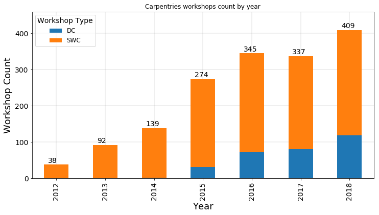

# Figure X: Geographic Reach

Each dot on the map below represents one workshop since 2012.

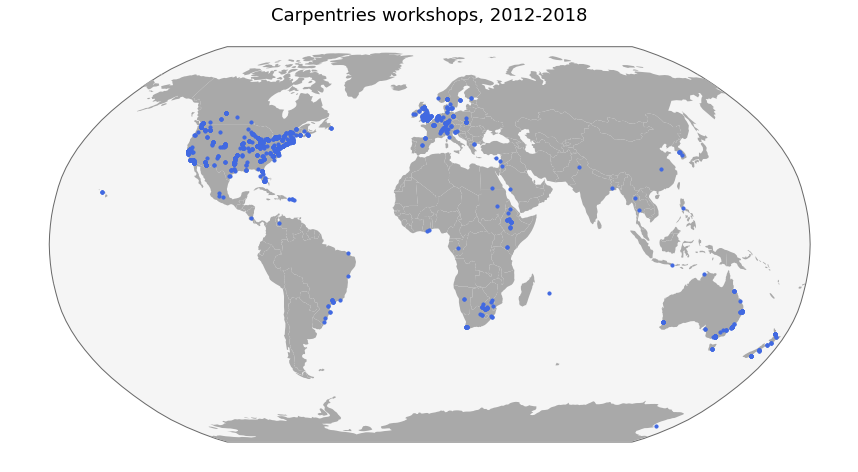

## Figure X: Countries hosting 10 or more workshops

This bar chart looks only at countries that have hosted 10 or more workshops since 2012. For each country, the number of workshops run each year is plotted. Data for 2018 is a projection. For most countries, this projection is calcuated by looking at the number of workshops run in the same time period in 2017. For workshops in Ethiopia and South Africa, without a long history with The Carpentries, this projection is calculated by looking at the average number of workshops per month in 2018.

Source data can be found in *Table X* in the Appendix.

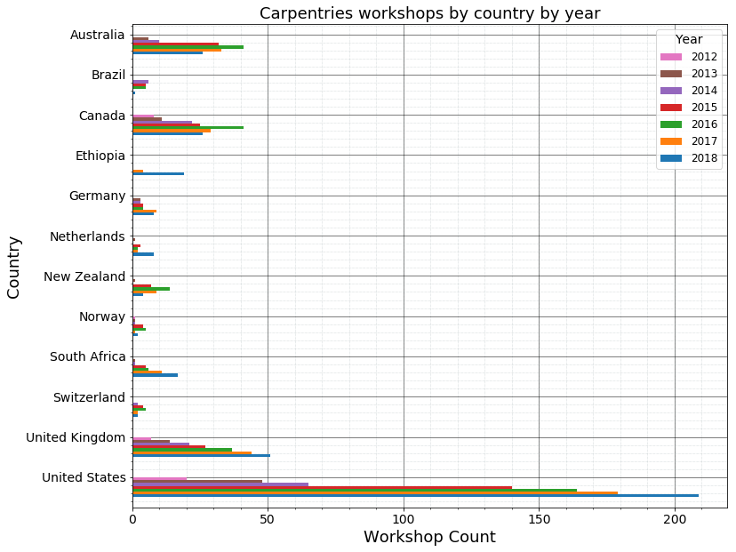

# Part 2: Learners

## Figure X: Workshop Attendance

This bar chart represents the total number of Software Carpentry (SWC) and Data Carpentry (DC) learners each year. Numbers for 2018 represent projected data. However, approximately 29% of 2018 workshops have unreported attendance. Source data can be found in Table X in the Appendix.

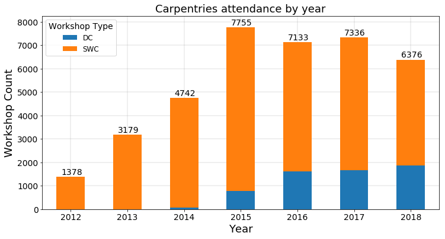

# Part 3: Instructor Training

## Overview

Over the last hundred years, researchers have discovered an enormous amount about how people learn and how best to teach them. Unfortunately, much of that knowledge has not yet been translated into common classroom practice, especially at the university level. To this goal, we offer an Instructor Training program.

This two-day class has the following overall goals:

- Introduce trainees to evidence-based best-practices of teaching.
- Teach how to create a positive environment for learners at Carpentries workshops.
- Provide opportunities for trainees to practice and build your teaching skills.
- Help trainees become integrated into the Carpentry community.
- Prepare trainees to use these teaching skills in teaching Carpentry workshops.

Because we have only two days, some things are beyond the scope of this class. We do not teach:

- How to program in R or Python, use git, or any of the other topics taught in Carpentry workshops.
- How to create lessons from scratch (although trainees will have a good start on the principles behind that sort of work if inspired to learn more). This training is based on our constantly revised and updated curriculum (https://carpentries.github.io/instructor-training/ ).

## Figure X: Instructor Training Applications by Previous Experience in Teaching

Source data can be found in Table X of the Appendix.

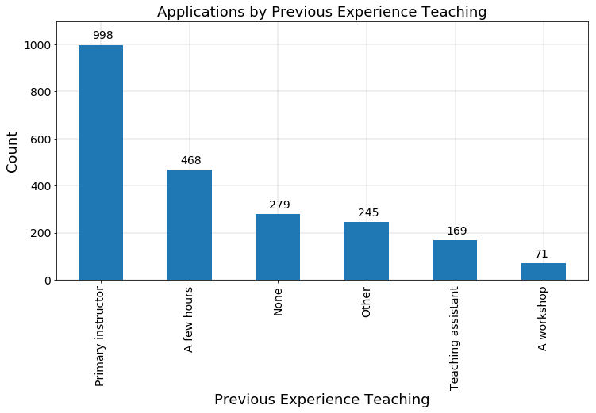

## Figure X: Instructor Training Applications by Previous Training in Teaching

Source data can be found in Table X of the Appendix.

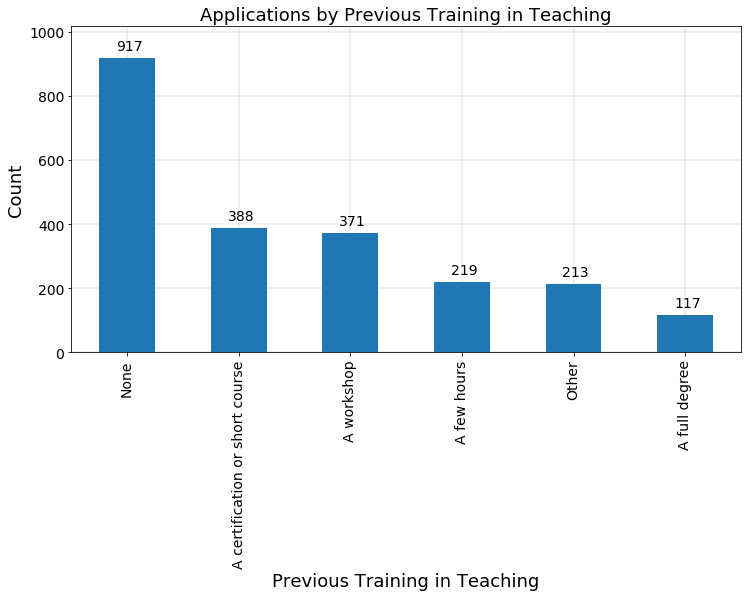

## Figure X: Instructor Training Applications by Areas of Expertise

Applicants can identify more than one area of expertise. Source data can be found in Table X of the Appendix.

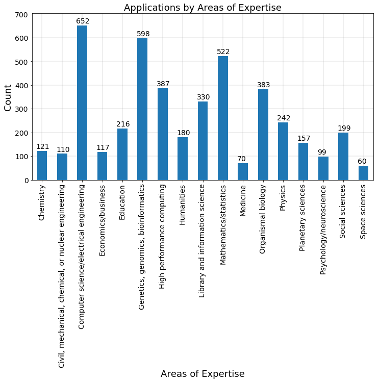

## Figure X: Instructor Training Applications by Occupation

Source data can be found in Table X of the Appendix.

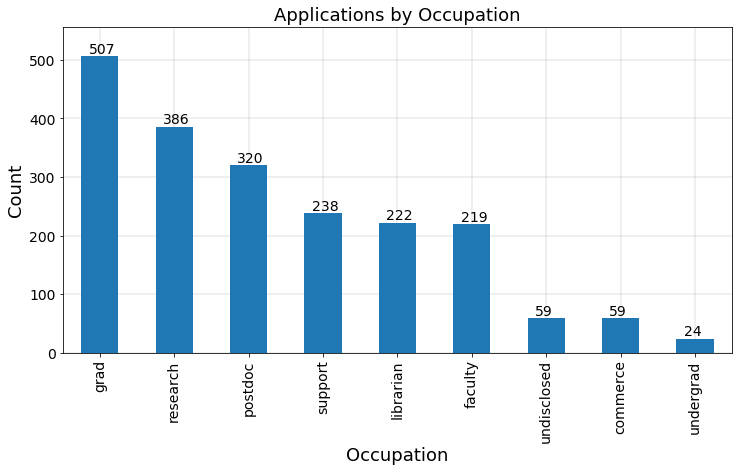

## Figure x: Instructor Training Events

Numbers for 2018 represent actual data through September 2018. Source data can be found in Table X of the Appendix.

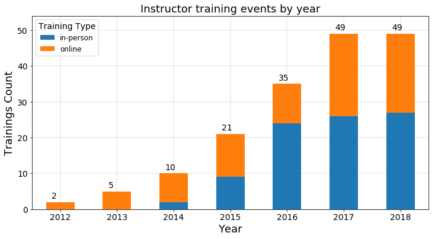

## Figure X: Badging Rates at online vs. inperson events

This charat shows the average of the percent badged each year. Source data can be found in Table X of the Appendix.

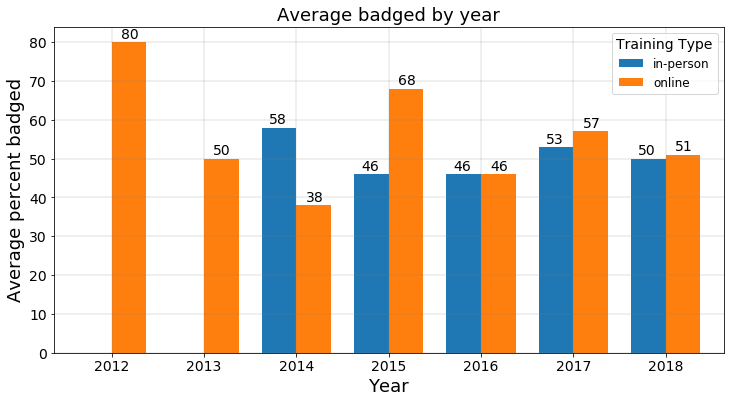

## Figure X: Badged Instructors

Cumulative count by year of all instructors badged through September 2018. As of September 2018, The Carpentries had a total of 1654 instructors.

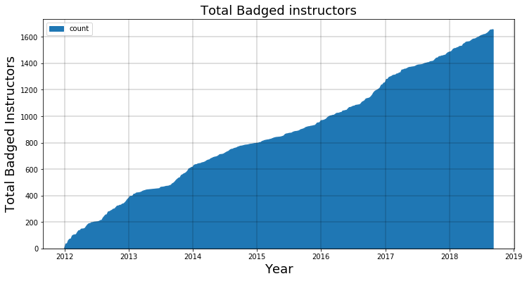

# Part 4: Teaching

## Figure X: Teaching Frequency

Source data can be found in Table X of the Appendix.

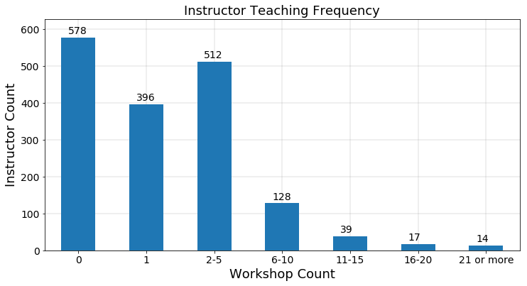

# Part 5: Trainers

## Figure X: New Trainers by Year

As of September 2018, The Carpentries has 57 Instructor Trainers on board. Source data can be found in Table X of the Appendix.

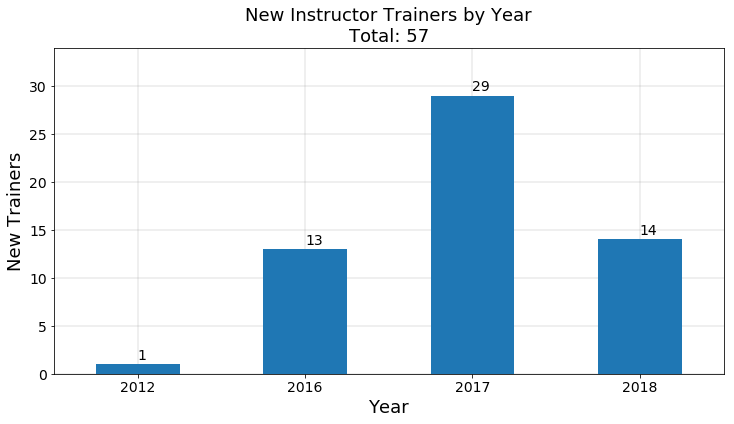

## Figure X: Trainers by Country

Source data can be found in Table X of the Appendix.

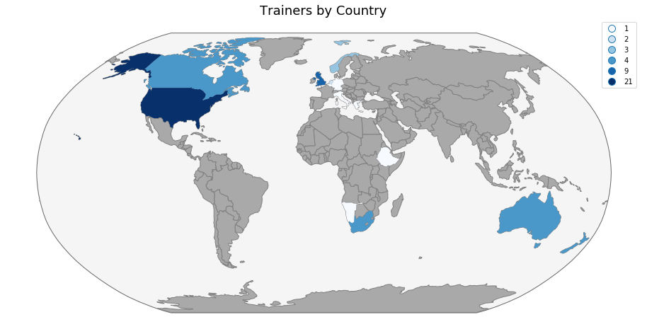

# Appendix

## Table X: Workshops by Carpentry by Year

| Workshop Type Year | DC | SWC | row total |
| --- | --- | --- | --- |
| 2012 | 0 | 38 | 38 |
| 2013 | 0 | 92 | 92 |
| 2014 | 2 | 137 | 139 |
| 2015 | 31 | 243 | 274 |
| 2016 | 72 | 273 | 345 |
| 2017 | 81 | 256 | 337 |
| 2018 | 119 | 290 | 409 |
| column total | 305 | 1329 | 1634 |

## Table X: Workshops by Country by Year

| Year Country | 2012 | 2013 | 2014 | 2015 | 2016 | 2017 | 2018 | row total |
| --- | --- | --- | --- | --- | --- | --- | --- | --- |
| Antarctica | 0 | 0 | 0 | 0 | 0 | 0 | 1 | 1 |
| Australia | 0 | 6 | 10 | 32 | 41 | 33 | 26 | 148 |
| Belgium | 0 | 0 | 0 | 1 | 0 | 1 | 1 | 3 |
| Botswana | 0 | 0 | 0 | 0 | 0 | 1 | 0 | 1 |
| Brazil | 0 | 0 | 6 | 5 | 5 | 0 | 1 | 17 |
| Canada | 8 | 11 | 22 | 25 | 41 | 29 | 26 | 162 |
| China | 0 | 1 | 0 | 0 | 0 | 0 | 0 | 1 |
| Colombia | 0 | 0 | 0 | 0 | 1 | 0 | 0 | 1 |
| Cyprus | 0 | 0 | 1 | 0 | 0 | 0 | 0 | 1 |
| Denmark | 0 | 0 | 1 | 0 | 2 | 2 | 2 | 7 |
| Ethiopia | 0 | 0 | 0 | 0 | 0 | 4 | 19 | 23 |
| Finland | 0 | 0 | 0 | 2 | 0 | 0 | 1 | 3 |
| France | 1 | 2 | 0 | 1 | 3 | 0 | 2 | 9 |
| Gabon | 0 | 0 | 0 | 0 | 0 | 1 | 0 | 1 |
| Germany | 0 | 3 | 3 | 4 | 4 | 9 | 8 | 31 |
| Ghana | 0 | 0 | 1 | 0 | 0 | 1 | 0 | 2 |
| Greece | 0 | 0 | 0 | 0 | 1 | 0 | 1 | 2 |
| India | 0 | 0 | 0 | 1 | 0 | 0 | 0 | 1 |
| Indonesia | 0 | 0 | 0 | 1 | 0 | 0 | 0 | 1 |
| Ireland | 0 | 0 | 0 | 0 | 0 | 0 | 2 | 2 |
| Italy | 1 | 0 | 1 | 0 | 2 | 0 | 2 | 6 |
| Jordan | 0 | 0 | 1 | 0 | 0 | 0 | 0 | 1 |
| Kenya | 0 | 0 | 0 | 1 | 1 | 0 | 0 | 2 |
| Korea, Republic of | 0 | 0 | 0 | 4 | 1 | 0 | 0 | 5 |
| Lebanon | 0 | 1 | 0 | 0 | 0 | 0 | 0 | 1 |
| Mauritius | 0 | 0 | 0 | 0 | 0 | 1 | 0 | 1 |
| Mexico | 0 | 0 | 0 | 0 | 1 | 1 | 1 | 3 |
| Namibia | 0 | 0 | 0 | 0 | 1 | 1 | 0 | 2 |
| Netherlands | 0 | 1 | 0 | 3 | 2 | 2 | 8 | 16 |
| New Zealand | 0 | 1 | 0 | 7 | 14 | 9 | 4 | 35 |
| Norway | 1 | 1 | 1 | 4 | 5 | 1 | 2 | 15 |
| Pakistan | 0 | 0 | 0 | 0 | 0 | 0 | 1 | 1 |
| Philippines | 0 | 0 | 0 | 0 | 1 | 0 | 0 | 1 |
| Poland | 0 | 1 | 1 | 2 | 4 | 1 | 0 | 9 |
| Puerto Rico | 0 | 0 | 0 | 0 | 1 | 0 | 2 | 3 |
| Saudi Arabia | 0 | 1 | 0 | 0 | 0 | 0 | 0 | 1 |
| Slovenia | 0 | 0 | 0 | 1 | 0 | 0 | 0 | 1 |
| South Africa | 0 | 1 | 1 | 5 | 6 | 11 | 17 | 41 |
| Spain | 0 | 0 | 1 | 1 | 1 | 2 | 2 | 7 |
| Sudan | 0 | 0 | 0 | 0 | 0 | 0 | 1 | 1 |
| Sweden | 0 | 0 | 1 | 1 | 1 | 1 | 3 | 7 |
| Switzerland | 0 | 0 | 2 | 4 | 5 | 2 | 2 | 15 |
| Thailand | 0 | 0 | 0 | 1 | 0 | 1 | 0 | 2 |
| United Kingdom | 7 | 14 | 21 | 27 | 37 | 44 | 51 | 201 |
| United States | 20 | 48 | 65 | 140 | 164 | 179 | 209 | 825 |
| Venezuela, Bolivarian Republic of | 0 | 0 | 0 | 1 | 0 | 0 | 0 | 1 |
| column total | 38 | 92 | 139 | 274 | 345 | 337 | 395 | 1620 |

## Attendance by Carpentry by Year

| Workshop Type Year | DC | SWC | row total |
| --- | --- | --- | --- |
| 2012 | 0 | 1378 | 1378 |
| 2013 | 0 | 3179 | 3179 |
| 2014 | 59 | 4683 | 4742 |
| 2015 | 790 | 6965 | 7755 |
| 2016 | 1604 | 5529 | 7133 |
| 2017 | 1659 | 5677 | 7336 |
| 2018 | 1864 | 4512 | 6376 |
| column total | 5976 | 31923 | 37899 |

## Instructor Training Applications by Previous Experience Teaching

| Previous Experience | Count |
| --- | --- |
| Primary instructor | 998 |
| A few hours | 468 |
| None | 279 |
| Other | 245 |
| Teaching assistant | 169 |
| A workshop | 71 |
| column total | 2230 |

## Instructor Training Applications by Previous Training in Teaching

| Previous Training | Count |
| --- | --- |
| None | 917 |
| A certification or short course | 388 |
| A workshop | 371 |
| A few hours | 219 |
| Other | 213 |
| A full degree | 117 |
| column total | 2225 |

## Instructor Training Applications by Areas of Expertise

Totals are not included as applicants can select more than one area of expertise.

| Expertise areas | Count |
| --- | --- |
| Chemistry | 121 |
| Civil, mechanical, chemical, or nuclear engineering | 110 |
| Computer science/electrical engineering | 652 |
| Economics/business | 117 |
| Education | 216 |
| Genetics, genomics, bioinformatics | 598 |
| High performance computing | 387 |
| Humanities | 180 |
| Library and information science | 330 |
| Mathematics/statistics | 522 |
| Medicine | 70 |
| Organismal biology | 383 |
| Physics | 242 |
| Planetary sciences | 157 |
| Psychology/neuroscience | 99 |
| Social sciences | 199 |
| Space sciences | 60 |

## Instructor Training Applications by Occupation

| Occupation | Count |
| --- | --- |
| grad | 507 |
| research | 386 |
| postdoc | 320 |
| support | 238 |
| librarian | 222 |
| faculty | 219 |
| undisclosed | 59 |
| commerce | 59 |
| undergrad | 24 |
| column total | 2034 |

## Instructor Training Events by Year

| Type Year | in-person | online | row total |
| --- | --- | --- | --- |
| 2012 | 0 | 2 | 2 |
| 2013 | 0 | 5 | 5 |
| 2014 | 2 | 8 | 10 |
| 2015 | 9 | 12 | 21 |
| 2016 | 24 | 11 | 35 |
| 2017 | 26 | 23 | 49 |
| 2018 | 27 | 22 | 49 |
| column total | 88 | 83 | 171 |

## Average Badged by Instructor Training Event Type by Year

| Percent Badged Year | in-person | online |
| --- | --- | --- |
| 2012 | 0 | 80 |
| 2013 | 0 | 50 |
| 2014 | 58 | 38 |
| 2015 | 46 | 68 |
| 2016 | 46 | 46 |
| 2017 | 53 | 57 |
| 2018 | 50 | 51 |

## Instructor Teaching Frequency

|  | workshops taught | count |
| --- | --- | --- |
| count | 0 | 578 |
|  | 1 | 396 |
|  | 2-5 | 512 |
|  | 6-10 | 128 |
|  | 11-15 | 39 |
|  | 16-20 | 17 |
|  | 21 or more | 14 |

## New Instructor Trainers by Year

| year | count |
| --- | --- |
| 2012 | 1 |
| 2016 | 13 |
| 2017 | 29 |
| 2018 | 14 |
| column total | 57 |

## Instructor Trainers by Country

| country | count |
| --- | --- |
| Australia | 4 |
| Belgium | 1 |
| Canada | 4 |
| Ethiopia | 1 |
| Germany | 1 |
| Greece | 1 |
| Italy | 1 |
| Namibia | 1 |
| Netherlands | 2 |
| New Zealand | 4 |
| Norway | 3 |
| South Africa | 4 |
| United Kingdom | 9 |
| United States | 21 |
| column total | 57 |